# PS4

# 2 R4DS Chapter 10

1. Firstly, we can print out the object to see whether the object is a tibble. If the object is a tibble, there will be “A tibble:” on the first line. Secondly, we can test if the object is a tibble by using is_tibble().

```r
#print mtcars
mtcars
```

```
##                      mpg cyl  disp  hp drat    wt  qsec vs am gear carb
## Mazda RX4           21.0   6 160.0 110 3.90 2.620 16.46  0  1    4    4
## Mazda RX4 Wag       21.0   6 160.0 110 3.90 2.875 17.02  0  1    4    4
## Datsun 710          22.8   4 108.0  93 3.85 2.320 18.61  1  1    4    1
## Hornet 4 Drive      21.4   6 258.0 110 3.08 3.215 19.44  1  0    3    1
## Hornet Sportabout   18.7   8 360.0 175 3.15 3.440 17.02  0  0    3    2
## Valiant             18.1   6 225.0 105 2.76 3.460 20.22  1  0    3    1
## Duster 360          14.3   8 360.0 245 3.21 3.570 15.84  0  0    3    4
## Merc 240D           24.4   4 146.7  62 3.69 3.190 20.00  1  0    4    2
## Merc 230            22.8   4 140.8  95 3.92 3.150 22.90  1  0    4    2
## Merc 280            19.2   6 167.6 123 3.92 3.440 18.30  1  0    4    4
## Merc 280C           17.8   6 167.6 123 3.92 3.440 18.90  1  0    4    4
## Merc 450SE          16.4   8 275.8 180 3.07 4.070 17.40  0  0    3    3
## Merc 450SL          17.3   8 275.8 180 3.07 3.730 17.60  0  0    3    3
## Merc 450SLC         15.2   8 275.8 180 3.07 3.780 18.00  0  0    3    3
## Cadillac Fleetwood  10.4   8 472.0 205 2.93 5.250 17.98  0  0    3    4
## Lincoln Continental 10.4   8 460.0 215 3.00 5.424 17.82  0  0    3    4
## Chrysler Imperial   14.7   8 440.0 230 3.23 5.345 17.42  0  0    3    4
## Fiat 128            32.4   4  78.7  66 4.08 2.200 19.47  1  1    4    1
## Honda Civic         30.4   4  75.7  52 4.93 1.615 18.52  1  1    4    2
## Toyota Corolla      33.9   4  71.1  65 4.22 1.835 19.90  1  1    4    1
## Toyota Corona       21.5   4 120.1  97 3.70 2.465 20.01  1  0    3    1
## Dodge Challenger    15.5   8 318.0 150 2.76 3.520 16.87  0  0    3    2
## AMC Javelin         15.2   8 304.0 150 3.15 3.435 17.30  0  0    3    2
## Camaro Z28          13.3   8 350.0 245 3.73 3.840 15.41  0  0    3    4
## Pontiac Firebird    19.2   8 400.0 175 3.08 3.845 17.05  0  0    3    2
## Fiat X1-9           27.3   4  79.0  66 4.08 1.935 18.90  1  1    4    1
## Porsche 914-2       26.0   4 120.3  91 4.43 2.140 16.70  0  1    5    2
## Lotus Europa        30.4   4  95.1 113 3.77 1.513 16.90  1  1    5    2
## Ford Pantera L      15.8   8 351.0 264 4.22 3.170 14.50  0  1    5    4
## Ferrari Dino        19.7   6 145.0 175 3.62 2.770 15.50  0  1    5    6
## Maserati Bora       15.0   8 301.0 335 3.54 3.570 14.60  0  1    5    8
## Volvo 142E          21.4   4 121.0 109 4.11 2.780 18.60  1  1    4    2
```

```r
#convert mtcars to tibble
as_tibble(mtcars)
```

```
## # A tibble: 32 x 11
##      mpg   cyl  disp    hp  drat    wt  qsec    vs    am  gear  carb
##  * <dbl> <dbl> <dbl> <dbl> <dbl> <dbl> <dbl> <dbl> <dbl> <dbl> <dbl>
##  1  21       6  160    110  3.9   2.62  16.5     0     1     4     4
##  2  21       6  160    110  3.9   2.88  17.0     0     1     4     4
##  3  22.8     4  108     93  3.85  2.32  18.6     1     1     4     1
##  4  21.4     6  258    110  3.08  3.22  19.4     1     0     3     1
##  5  18.7     8  360    175  3.15  3.44  17.0     0     0     3     2
##  6  18.1     6  225    105  2.76  3.46  20.2     1     0     3     1
##  7  14.3     8  360    245  3.21  3.57  15.8     0     0     3     4
##  8  24.4     4  147.    62  3.69  3.19  20       1     0     4     2
##  9  22.8     4  141.    95  3.92  3.15  22.9     1     0     4     2
## 10  19.2     6  168.   123  3.92  3.44  18.3     1     0     4     4
## # ... with 22 more rows
```

```r
is_tibble(mtcars)
```

```
## [1] FALSE
```

2. The first operartion: r could extract a column for dataframes by partial column name, however, r cannot do that for tibbles. The second operation: As for dataframes, r returns a vector instead of a dataframe when we ask for subsetting one column. And for tibbles, r returns a tibble when we ask for subsetting one column. The third operation: As for dataframes, r returns a dataframe when we ask for subsetting more than one columns. And for tibbles, r returns a tibble

```r
d_f <- data.frame(abc = 1, xyz = "a")
d_f$x
```

```
## [1] a
## Levels: a
```

```r
d_f[, "xyz"]
```

```
## [1] a
## Levels: a
```

```r
d_f[, c("abc", "xyz")]
```

```
##   abc xyz
## 1   1   a
```

```r
t_b <- tibble(abc = 1, xyz = "a")
t_b$x
```

```r
t_b[, "xyz"]
```

```
## # A tibble: 1 x 1
##   xyz
##   <chr>
## 1 a
```

```r
t_b[, c("abc", "xyz")]
```

```
## # A tibble: 1 x 2
##     abc xyz
##   <dbl> <chr>
## 1     1 a
```

```r
df[[var]]
```

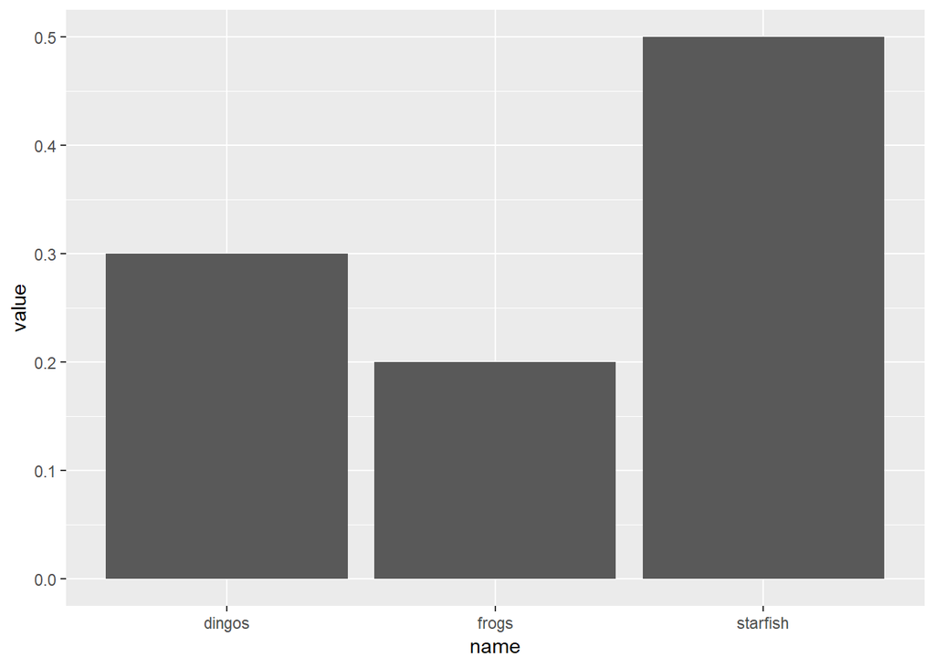

```r
data_from_a_paper <- c("frogs" = 0.2, "dingos" = 0.3, "starfish" = 0.5)
tbl_data <- tibble::enframe(data_from_a_paper)
ggplot(tbl_data) +
  geom_col(aes(x = name, y = value))
```

5. n_extra, it decides number of extra columns to print abbreviated information for.

# 3 R4DS Chapter 11

1. The code is as following:

```r
read_delim("file.xxx",sep="|")
```

2. We need to specify the arguments delim and quote to read the text into a data frame

```r
read_delim("x,y\n1,'d,b'",delim=",",quote = "'")
```

```
## # A tibble: 1 x 2
##       x y
##   <int> <chr>
## 1     1 d,b
```

3. 1. There are only two inputs in the first line while there are three inputs in the second and third line, therefore the tibble only has two columns.
2. There are three inputs in the first line while there are only two inputs in the second and four in the third line, therefore the tibble gets a missing value in the second line and drops one input in the third line.
3. There are two inputs in the first line but there is only one input in the second line, therefore the tibble gets a missing value in the second line.In addtion, because ‘“1’ is with only one ’”’ instead of a pair of ‘“”’, it is treated as an int rather than a chr.
4. This inline file is successfully executed.
5. The inputs are seperated by “;” instead of “,”, therefore read_csv() cannot identify the seperation and “a;b” and “1;3” are both treated as one string. We should use read_csv2() here.

```r
#wrong
read_csv("a,b\n1,2,3\n4,5,6")
read_csv("a,b,c\n1,2\n1,2,3,4")
read_csv("a,b\n\"1")
read_csv("a,b\n1,2\na,b")
read_csv("a;b\n1;3")
```

4. The date_format and time_format options to locale() can respectively override the default mode of parsing date and time by creating a new locale and setting these arguments, making it possible to parse date and time in a format that is different from American one.  
   In Latin America, the date format is DMY(Date-Month-Year) and usually Spanish is used.

```r
parse_date("02/04/2008", "%d/%m/%Y" )
```

```
## [1] "2008-04-02"
```

```r
parse_date("2 abril 2008", "%d %B %Y", locale = locale("es") )
```

```
## [1] "2008-04-02"
```

```r
#1
d1 <- "January 1, 2010"
parse_date(d1, "%B %d, %Y")
```

```
## [1] "2010-01-01"
```

```r
#2
d2 <- "2015-Mar-07"
parse_date(d2,"%Y-%b-%d")
```

```
## [1] "2015-03-07"
```

```r
#3
d3 <- "06-Jun-2016"
parse_date(d3, "%d-%b-%Y")
```

```
## [1] "2016-06-06"
```

```r
#4
d4 <- c("August 19 (2015)", "July 1 (2015)")
parse_date(d4, "%B %d (%Y)")
```

```
## [1] "2015-08-19" "2015-07-01"
```

```r
#5
d5 <- "12/30/14" # Dec 30, 2014
parse_date(d5, "%m/%d/%y")
```

```
## [1] "2014-12-30"
```

```r
#6
t1 <- "1805"
parse_time(t1, "%H%M")
```

```
## 18:05:00
```

```r
#7
t2 <- "11:25:10.12 PM"
parse_datetime(t2, "%m:%d:%y.%I %p")
```

```
## [1] "2010-11-25 12:00:00 UTC"
```

6. The output includes four vectors:
1. begin, which describes the starting position of each column.
2. end, which describes the ending position of each column.
3. skip, which describes the number of lines to skip before reading data.
4. col_names, which are set to “X1 X2 X3 ……” in this situation.

```r
fwf_empty(readr_example("massey-rating.txt"))
```

```
## $begin
##  [1]  0  4  8 12 17 22 26 30 34 38 42 47 63
##
## $end
##  [1]  3  7 11 15 19 25 29 33 37 41 46 59 NA
##
## $skip
## [1] 0
##
## $col_names
##  [1] "X1"  "X2"  "X3"  "X4"  "X5"  "X6"  "X7"  "X8"  "X9"  "X10" "X11"
## [12] "X12" "X13"
```

7. The first output is “Error in structure(list(begin = begin, end = end, na = na, comment = comment), : argument”col_positions" is missing, with no default“.  
   The second output is a tibble.

```r
#attempt
read_fwf(readr_example("massey-rating.txt"))
```

```r
#right way to read
read_fwf(readr_example("massey-rating.txt"),
         fwf_empty(readr_example("massey-rating.txt"),
                   col_names = c("UCC", "PAY", "LAZ", "KPK", "RT", "COF", "BIH", "DII", "ENG", "ACU", "Rank", "Team", "Conf")),
         skip = 1)
```

```
## # A tibble: 10 x 13
##      UCC   PAY   LAZ   KPK    RT   COF   BIH   DII   ENG   ACU  Rank Team
##    <int> <int> <int> <int> <int> <int> <int> <int> <int> <int> <int> <chr>
##  1     1     1     1     1     1     1     1     1     1     1     1 Ohio~
##  2     2     2     2     2     2     2     2     2     4     2     2 Oreg~
##  3     3     4     3     4     3     4     3     4     2     3     3 Alab~
##  4     4     3     4     3     4     3     5     3     3     4     4 TCU
##  5     6     6     6     5     5     7     6     5     6    11     5 Mich~
##  6     7     7     7     6     7     6    11     8     7     8     6 Geor~
##  7     5     5     5     7     6     8     4     6     5     5     7 Flor~
##  8     8     8     9     9    10     5     7     7    10     7     8 Bayl~
##  9     9    11     8    13    11    11    12     9    14     9     9 Geor~
## 10    13    10    13    11     8     9    10    11     9    10    10 Miss~
## # ... with 1 more variable: Conf <chr>
```

8. It might be useful to read in only certain columns because sometimes the dataset can have too many columns, which makes it slow to read in all the columns and makes it unconvenient to grab the most important information we need.

```r
read_fwf(readr_example("massey-rating.txt"),
       fwf_empty(readr_example("massey-rating.txt"),
                 col_names = c("UCC", "PAY", "LAZ", "KPK", "RT", "COF", "BIH", "DII", "ENG", "ACU", "Rank", "Team", "Conf")),
       skip = 1)[,c("UCC", "Rank","Team")]
```

```
## # A tibble: 10 x 3
##      UCC  Rank Team
##    <int> <int> <chr>
##  1     1     1 Ohio St
##  2     2     2 Oregon
##  3     3     3 Alabama
##  4     4     4 TCU
##  5     6     5 Michigan St
##  6     7     6 Georgia
##  7     5     7 Florida St
##  8     8     8 Baylor
##  9     9     9 Georgia Tech
## 10    13    10 Mississippi
```

```r
#https://stackoverflow.com/questions/10085806/extracting-specific-columns-from-a-data-frame
```

# 4 Public Sector Application: Home Health Care Data

## 4.1 Data Ingestion

1. When there is a “*" listed in this file, it means there is a missing value.  
   Warning messages: (1): In read.table(“D:\R\dataset\HH PUF - Provider 2014.xlsx”) : line 1 appears to contain embedded nulls (2): In read.table(“D:\R\dataset\HH PUF - Provider 2014.xlsx”) : incomplete final line found by readTableHeader on ‘D:PUF - Provider 2014.xlsx’

```r
library(readxl)
library(testthat)
```

```r
#warning message
read.table("D:\\R\\dataset\\HH PUF - Provider 2014.xlsx")
```

```
## Warning in read.table("D:\\R\\dataset\\HH PUF - Provider 2014.xlsx"): line
## 1 appears to contain embedded nulls
```

```
## Warning in read.table("D:\\R\\dataset\\HH PUF - Provider 2014.xlsx"):
## incomplete final line found by readTableHeader on 'D:\R\dataset\HH PUF -
## Provider 2014.xlsx'
```

```
##               V1
## 1 PK\003\004\024
```

```r
#another way to read the provider file into R
provider <- read_xlsx("D:\\R\\dataset\\HH PUF - Provider 2014.xlsx",sheet = 3,na="*")
#test the number of rows
test_that("we have the right number of rows",expect_equal(nrow(provider),10867))
```

2. Read Medicare’s home health PUF by provider and HHRG for 2014:

```r
provider_hhrg <- read_xlsx("D:\\R\\dataset\\HH PUF - Provider by HHRG 2014.xlsx",sheet = 3,na="*")
#test the number of rows
test_that("we have the right number of rows",expect_equal(nrow(provider_hhrg),104920))
```

3. Read Medicare’s 2014 case-mix weights file:

```r
case_mix_weight <- read_csv("D:\\R\\dataset\\CY 2014 Final HH PPS Case-Mix Weights.csv")
colnames(case_mix_weight)[5] <- "weights_2014"
case_mix_weight[,4] <- NULL
test_that("we have the right number of rows",expect_equal(nrow(case_mix_weight),153))
```

## 4.2 Institutional Research

1. Five examples of services that home health agencies: skilled nursing, physical therapy, occupational therapy, speech therapy and home health aide.
2. An HHRG code is a code identifying to which Home Health Resource Group a patient belongs.Home Health Resource Groups divides patients into different groups based on the number of their therapy visits, their clinical levels, functional levels and their timing of visit.
3. A HCC score evaluates whether a patient, compared to the overall average for the entire Medicare population, will cause a higher or lower spending of Medicare. A patient with a higher HCC score is expected to cause more spending and if the HCC score is higher than 1.08, the patient is expected to cause a higher spending than the average and vice versa.  
   A patient with a HCC score of 0.75 will probably cost the Medicare much less than the average level of the entire Medicare population.  
   A patient with a HCC score of 1.5 will probably cost the Medicare much more than average level of the entire Medicare population.
4. A LUPA stands for “low utilization payment adjustment”, which means if a patient uses the home health agency service very few times (he or she visits the home health agency four or fewer times in a 60-day episode), he or she will get one reimbursement for each visit respectively rather than get a total reimbursement for an episode in the usual situation.

## 4.3 Data Validation

1. The numbers from provider and provider_hhrg do not align. The reason why they do not align may include the missing values in provider dataset.

```r
#number of beneficiaries in provider : 3442614
summarise(provider, n_m_bene = sum(`Male Beneficiaries`, na.rm=TRUE), n_f_bene=sum(`Female Beneficiaries`,na.rm = TRUE), n_total=n_m_bene+n_f_bene)
```

```
## # A tibble: 1 x 3
##   n_m_bene n_f_bene n_total
##      <dbl>    <dbl>   <dbl>
## 1  1300221  2142393 3442614
```

```r
#number of beneficiaries in provider_hhrg : 3468099
summarise(provider_hhrg, n_total=sum(`Distinct Beneficiaries`))
```

```
## # A tibble: 1 x 1
##   n_total
##     <dbl>
## 1 3468099
```

```r
#number of beneficiaties from other public document: 3.4 million
#http://www.medpac.gov/docs/default-source/reports/chapter-8-home-health-care-services-march-2016-report-.pdf
```

2. The numbers from provider and provider_hhrg do not align. The reason why they do not align may include the difference in methodology and that the column “Total Episodes” in provider_hhrg is only the total count of non-LUPA episodes while the provider dataset provides both the number of non LUPA and LUPA.

```r
# total number of episodes in provider : 6534036
summarise(provider, nLUPA_epi = sum(`Total Episodes (non-LUPA)`, na.rm=TRUE), LUPA_epi=sum(`Total LUPA Episodes`,na.rm = TRUE), n_total=nLUPA_epi+LUPA_epi)
```

```
## # A tibble: 1 x 3
##   nLUPA_epi LUPA_epi n_total
##       <dbl>    <dbl>   <dbl>
## 1   5975644   558392 6534036
```

```r
# total number of episodes in provider_hhrg : 4194441
summarise(provider_hhrg, n_total=sum(`Total Episodes`))
```

```
## # A tibble: 1 x 1
##   n_total
##     <dbl>
## 1 4194441
```

3. The two columns “Provider ID” and “HHRG” together uniquely identify any row in provider_hhrg. By concatenating these two columns, we can create a new column “unique ID” and there are 104920 distinct values in this column, which is exactly the number of rows in provider_hhrg.

```r
provider_hhrg$unique_ID <- paste(provider_hhrg$`Provider ID`,provider_hhrg$HHRG)
summarise(provider_hhrg, n_distinct=n_distinct(unique_ID))
```

```
## # A tibble: 1 x 1
##   n_distinct
##        <int>
## 1     104920
```